# Variables instrumentales: aplicación con la EPH

```r
library(tidyverse)
```

```r
library(readxl)
```

## 1) Preprocesamiento de datos

```r
eph_individual<- read_excel("C:/Users/faust/Desktop/2023/Maestría/EnfoqueEstadisticodelAprendizaje/Trabajo_Final/datasets/usu_individual_T223.xlsx")
```

```r
eph_individual %>% head(5)
```

| CODUSU | ANO4 | TRIMESTRE | NRO_HOGAR | COMPONENTE | H15 | REGION | MAS_500 | AGLOMERADO | PONDERA | CH03 | CH04 | CH05 | CH06 | CH07 | CH08 | CH09 | CH10 | CH11 | CH12 | CH13 | CH14 | CH15 | CH15_COD | CH16 | CH16_COD | NIVEL_ED | ESTADO | CAT_OCUP | CAT_INAC | … |
| --- | --- | --- | --- | --- | --- | --- | --- | --- | --- | --- | --- | --- | --- | --- | --- | --- | --- | --- | --- | --- | --- | --- | --- | --- | --- | --- | --- | --- | --- | --- |
| TQRMNOVRTHJLMOCDEIJAH00785878 | 2023 | 2 | 1 | 1 | 1 | 1 | S | 33 | 435 | 1 | 2 | 14/08/1982 | 40 | 3 | 1 | 1 | 2 | 0 | 6 | 1 | NA | 1 | NA | 1 | NA | 6 | 1 | 3 | 0 | … |
| TQRMNOVRTHJLMOCDEIJAH00785878 | 2023 | 2 | 1 | 2 | 1 | 1 | S | 33 | 435 | 3 | 1 | 06/11/1999 | 23 | 5 | 1 | 1 | 2 | 0 | 4 | 1 | NA | 1 | NA | 1 | NA | 4 | 1 | 3 | 0 | … |
| TQRMNOVRTHJLMOCDEIJAH00785878 | 2023 | 2 | 1 | 3 | 0 | 1 | S | 33 | 435 | 3 | 2 | 02/11/2016 | 6 | 5 | 1 | 1 | 1 | 2 | 1 | 2 | 0 | 1 | NA | 1 | NA | 7 | 4 | 0 | 3 | … |
| TQRMNORXRHMLLPCDEIJAH00802612 | 2023 | 2 | 1 | 1 | 1 | 1 | S | 33 | 1163 | 1 | 2 | 19/02/1948 | 75 | 4 | 1 | 1 | 2 | 0 | 7 | 2 | 1 | 1 | NA | 1 | NA | 5 | 3 | 0 | 1 | … |
| TQRMNOUVTHKKMPCDEIIAD00785342 | 2023 | 2 | 1 | 1 | 1 | 1 | S | 32 | 1909 | 1 | 1 | 17/09/1987 | 35 | 2 | 4 | 1 | 2 | 0 | 4 | 1 | NA | 4 | 202 | 1 | NA | 4 | 1 | 2 | 0 | … |

```r
eph_hogares<- read_excel("C:/Users/faust/Desktop/2023/Maestría/EnfoqueEstadisticodelAprendizaje/Trabajo_Final/datasets/usu_hogar_T223.xlsx")
```

```r
eph_hogares %>% head(5)
```

| CODUSU | ANO4 | TRIMESTRE | NRO_HOGAR | REALIZADA | REGION | MAS_500 | AGLOMERADO | PONDERA | IV1 | IV1_ESP | IV2 | IV3 | IV3_ESP | IV4 | IV5 | IV6 | IV7 | IV7_ESP | IV8 | IV9 | IV10 | IV11 | IV12_1 | IV12_2 | IV12_3 | II1 | II2 | II3 | II3_1 | … |
| --- | --- | --- | --- | --- | --- | --- | --- | --- | --- | --- | --- | --- | --- | --- | --- | --- | --- | --- | --- | --- | --- | --- | --- | --- | --- | --- | --- | --- | --- | --- |
| TQRMNOPUUHJLKRCDEFMDB00782399 | 2023 | 2 | 1 | 1 | 43 | N | 6 | 254 | 1 | NA | 7 | 1 | NA | 1 | 1 | 1 | 1 | NA | 1 | 1 | 1 | 1 | 2 | 2 | 2 | 7 | 3 | 2 | 0 | … |
| TQRMNORQRHLMKSCDEFMDB00804030 | 2023 | 2 | 1 | 1 | 43 | N | 6 | 195 | 1 | NA | 1 | 1 | NA | 1 | 1 | 1 | 1 | NA | 1 | 1 | 1 | 1 | 2 | 2 | 2 | 1 | 1 | 2 | 0 | … |
| TQRMNOTVVHMOKTCDEFMDB00804031 | 2023 | 2 | 1 | 1 | 43 | N | 6 | 228 | 2 | NA | 2 | 1 | NA | 9 | 1 | 1 | 1 | NA | 1 | 1 | 1 | 1 | 2 | 2 | 2 | 2 | 1 | 2 | 0 | … |
| TQRMNOPUTHLLMLCDEIIAD00806980 | 2023 | 2 | 1 | 1 | 1 | S | 32 | 2816 | 2 | NA | 2 | 1 | NA | 1 | 1 | 1 | 1 | NA | 1 | 1 | 1 | 1 | 2 | 2 | 2 | 2 | 2 | 2 | 0 | … |
| TQRMNOPYPHMOLLCDEGNFJ00800107 | 2023 | 2 | 2 | 1 | 44 | N | 17 | 177 | 2 | NA | 3 | 1 | NA | 4 | 1 | 1 | 1 | NA | 1 | 1 | 1 | 1 | 2 | 2 | 2 | 3 | 1 | 2 | 0 | … |

```r
eph_individual<- eph_individual %>% select(CODUSU, NRO_HOGAR, CH03, PP08D1, CH06,
                                           CH10, CH13, CH12, CH14)
```

CODUSU: Código para distinguir viviendas, permite aparearlas con Hogares y Personas. Además permite hacer el seguimiento a través de los trimestres.

NRO_HOGAR: Código para distinguir Hogares, permite aparearlos con Personas.

CH03: Relación de parentesco.

PP08D1: Ingreso de la ocupación principal de los asalariados.

CH06: Años cumplidos.

CH10: ¿Asiste o asistió a algún establecimiento educativo? (colegio, escuela, universidad).

CH12: ¿Cuál es el nivel más alto que cursa o cursó?

CH13: ¿Finalizó ese nivel?

CH14: ¿Cuál fue el último año que aprobó?

```r
# AÑOS DE EDUCACIÓN
# Jardín/preescolar cuenta como 1
eph_individual <- eph_individual %>%
                        mutate(educacion = case_when(CH10 == 3 ~ 0, # Nunca asistió
                                   CH06 < 2 ~ 0, # Menores de dos años
                                   CH12 == 9 ~ 0,  # Educación especial
                                   CH13 == 2 & CH12 == 1 ~ 0 # # Jardín/preescolar
                                   ))

# Primaria
eph_individual <- eph_individual %>%
  mutate(educacion = case_when(
    CH13 == 2 & CH12 == 2 & CH14 == 0 ~ 1,
    CH13 == 2 & CH12 == 2 & CH14 == 1 ~ 2,
    CH13 == 2 & CH12 == 2 & CH14 == 2 ~ 3,
    CH13 == 2 & CH12 == 2 & CH14 == 3 ~ 4,
    CH13 == 2 & CH12 == 2 & CH14 == 4 ~ 5,
    CH13 == 2 & CH12 == 2 & CH14 == 5 ~ 6,
    CH13 == 2 & CH12 == 2 & CH14 == 6 ~ 7,
    TRUE ~ educacion
  ))

# EGB
eph_individual <- eph_individual %>%
  mutate(educacion = case_when(
    CH13 == 2 & CH12 == 3 & CH14 == 0 ~ 1,
    CH13 == 2 & CH12 == 3 & CH14 == 1 ~ 2,
    CH13 == 2 & CH12 == 3 & CH14 == 2 ~ 3,
    CH13 == 2 & CH12 == 3 & CH14 == 3 ~ 4,
    CH13== 2 & CH12 == 3 & CH14 == 4 ~ 5,
    CH13 == 2 & CH12 == 3 & CH14 == 5 ~ 6,
    CH13 == 2 & CH12 == 3 & CH14 == 6 ~ 7,
    CH13 == 2 & CH12 == 3 & CH14 == 7 ~ 8,
    CH13 == 2 & CH12 == 3 & CH14 == 8 ~ 9,
    TRUE ~ educacion
  ))

# Secundaria
eph_individual <- eph_individual %>%
  mutate(educacion = case_when(
    CH13 == 2 & CH12 == 4 & CH14 == 0 ~ 8,
    CH13 == 2 & CH12 == 4 & CH14 == 1 ~ 9,
    CH13 == 2 & CH12 == 4 & CH14 == 2 ~ 10,
    CH13 == 2 & CH12 == 4 & CH14 == 3 ~ 11,
    CH13 == 2 & CH12 == 4 & CH14 == 4 ~ 12,
    CH13 == 2 & CH12 == 4 & CH14 == 5 ~ 13,
    TRUE ~ educacion
  ))

# Resto de niveles educativos

# Polimodal
eph_individual <- eph_individual %>%
  mutate(educacion = case_when(
    CH13 == 2 & CH12 == 5 & CH14 == 0 ~ 10,
    CH13 == 2 & CH12 == 5 & CH14 == 1 ~ 11,
    CH13 == 2 & CH12 == 5 & CH14 == 2 ~ 12,
    CH13 == 2 & CH12 == 5 & CH14 == 3 ~ 13,
    TRUE ~ educacion
  ))

# Terciario
eph_individual <- eph_individual %>%
  mutate(educacion = case_when(
    CH13 == 2 & CH12 == 6 & CH14 == 0 ~ 13,
    CH13 == 2 & CH12 == 6 & CH14 == 1 ~ 14,
    CH13 == 2 & CH12 == 6 & CH14 >= 2 & CH14 < 98 ~ 15,
    TRUE ~ educacion
  ))

# Universitario
eph_individual <- eph_individual %>%
  mutate(educacion = case_when(
    CH13 == 2 & CH12 == 7 & CH14 == 0 ~ 13,
    CH13 == 2 & CH12 == 7 & CH14 == 1 ~ 14,
    CH13 == 2 & CH12 == 7 & CH14 == 2 ~ 15,
    CH13 == 2 & CH12 == 7 & CH14 == 3 ~ 16,
    CH13 == 2 & CH12 == 7 & CH14 == 4 ~ 17,
    CH13 == 2 & CH12 == 7 & CH14 >= 5 & CH14 < 98 ~ 18,
    TRUE ~ educacion
  ))

# Posgrado
eph_individual <- eph_individual %>%
  mutate(educacion = case_when(
    CH13 == 2 & CH12 == 8 & CH14 == 0 ~ 19,
    CH13 == 2 & CH12 == 8 & CH14 == 1 ~ 20,
    CH13 == 2 & CH12 == 8 & CH14 == 2 ~ 21,
    CH13 == 2 & CH12 == 8 & CH14 >= 3 & CH14 < 98 ~ 22,
    TRUE ~ educacion
  ))

# Completaron el nivel
eph_individual <- eph_individual %>%
  mutate(educacion = case_when(
    CH13 == 1 & CH12 == 1 ~ 1,
    CH13 == 1 & CH12 == 2 ~ 8,
    CH13 == 1 & CH12 == 3 ~ 11,
    CH13 == 1 & (CH12 == 4 | CH12 == 5) ~ 13,
    CH13 == 1 & CH12 == 6 ~ 16,
    CH13 == 1 & CH12 == 7 ~ 19,
    CH13 == 1 & CH12 == 8 ~ 23,
    TRUE ~ educacion
  ))
```

```r
eph_individual<- eph_individual %>% filter(!is.na(educacion))
```

```r
eph_hogares<- eph_hogares %>% select(CODUSU, NRO_HOGAR, IV2, IX_TOT) %>% mutate(personas_por_amb= IX_TOT/IV2)
```

IV2:ambientes que tiene la vivienda.

IX_TOT:cantidad de miembros del hogar.

```r
eph_cons<- eph_individual %>% left_join(., eph_hogares, by= c("CODUSU", "NRO_HOGAR"))
```

```r
eph_padre<- eph_cons %>% filter(CH03== 06)
```

```r
eph_hijo<- eph_cons %>% filter(CH03== 03 & PP08D1> 0)
```

```r
eph_jefe<- eph_cons %>% filter(CH03== 01 & PP08D1> 0)
```

```r
eph<- eph_hijo %>% left_join(., eph_jefe, by= c("CODUSU", "NRO_HOGAR"))
```

```r
eph<- eph %>% left_join(., eph_padre, by= c("CODUSU", "NRO_HOGAR"))
```

educacion va a ser la educación de la madre

```r
eph <- eph %>% filter(!is.na(educacion.y) | !is.na(educacion))
```

```r
eph<- eph %>% mutate(educacion= replace_na(educacion, 0)) %>% mutate(educacion.y=
                                                                       replace_na(educacion.y, 0))
```

```r
eph<- eph %>% mutate(educ_padre= educacion.y + educacion)
```

```r
eph<- eph %>% select(CODUSU, NRO_HOGAR, PP08D1.x, personas_por_amb.x, educacion.x, educ_padre)
```

```r
eph<- eph %>% rename(ingreso= PP08D1.x) %>% rename(personas_por_amb= personas_por_amb.x) %>% rename (educ= educacion.x)
```

## 2) Modelo 1: regresión lineal simple con MCO. El logaritmo del ingreso como variable dependiente y los años de educación como única variable regresora.

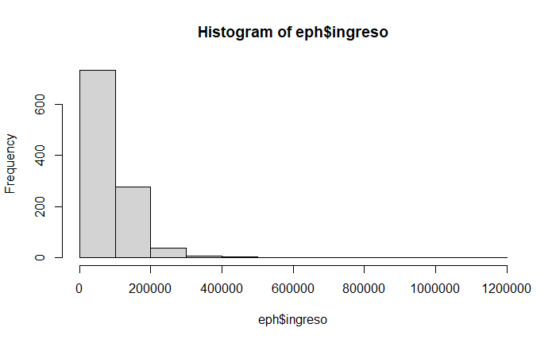

```r
hist(eph$ingreso)
```

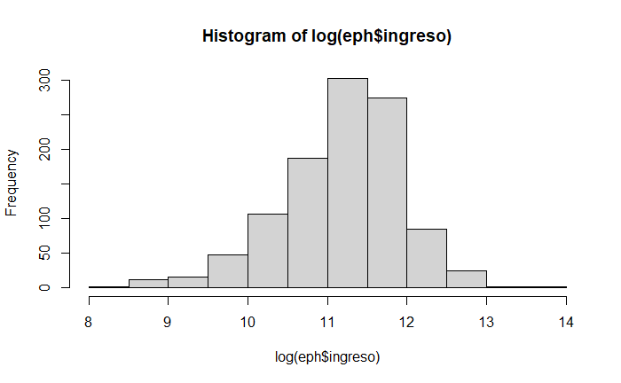

```r
hist(log(eph$ingreso))
```

```r
modelo_1<- lm(log(ingreso) ~ educ, data= eph)
```

```r
summary(modelo_1)
```

```
Call:
lm(formula = log(ingreso) ~ educ, data = eph)

Residuals:
    Min      1Q  Median      3Q     Max
-3.2093 -0.4385  0.0661  0.5376  2.4725

Coefficients:
             Estimate Std. Error t value Pr(>|t|)
(Intercept) 10.361247   0.119381  86.791  < 2e-16 ***
educ         0.061265   0.008938   6.855 1.21e-11 ***
---
Signif. codes:  0 ‘***’ 0.001 ‘**’ 0.01 ‘*’ 0.05 ‘.’ 0.1 ‘ ’ 1

Residual standard error: 0.732 on 1056 degrees of freedom
Multiple R-squared:  0.0426,    Adjusted R-squared:  0.04169
F-statistic: 46.98 on 1 and 1056 DF,  p-value: 1.215e-11
```

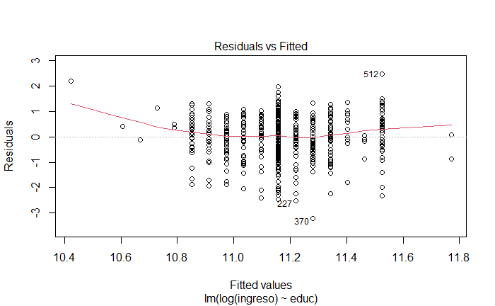

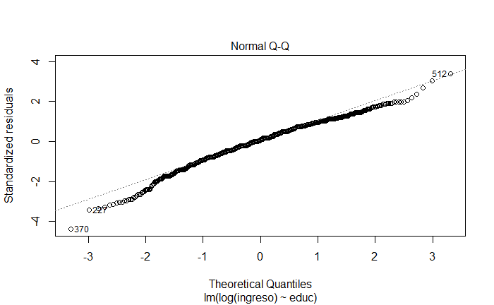

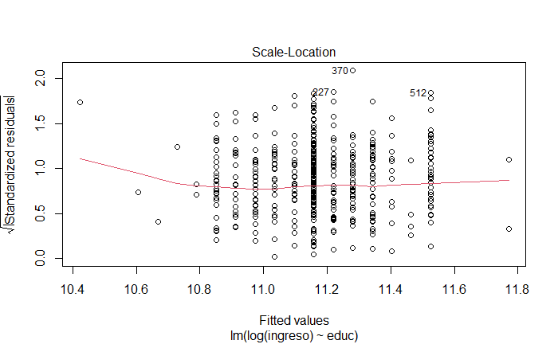

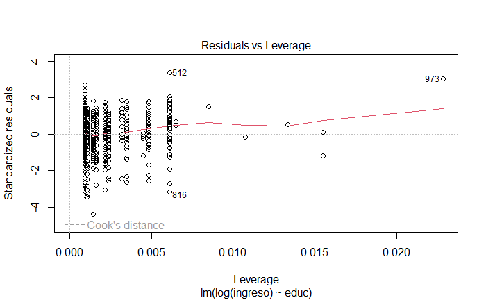

```r
plot(modelo_1)
```

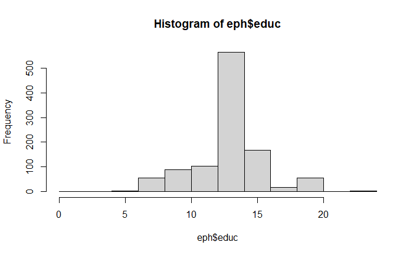

```r
hist(eph$educ)
```

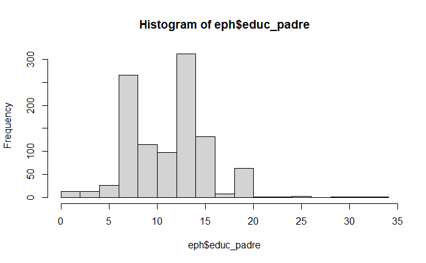

```r
hist(eph$educ_padre)
```

```r
library(corrr)

cor.test(eph$educ, eph$educ_padre, method="spearman")
```

```
    Spearman's rank correlation rho

data:  eph$educ and eph$educ_padre
S = 128380596, p-value < 2.2e-16
alternative hypothesis: true rho is not equal to 0
sample estimates:
      rho
0.3495798
```

```r
library(ivreg)
```

```r
modelo_2 <- ivreg(log(ingreso)~ educ | educ_padre , data = eph)
```

```r
summary(modelo_2)
```

```
Call:
ivreg(formula = log(ingreso) ~ educ | educ_padre, data = eph)

Residuals:
     Min       1Q   Median       3Q      Max
-3.31190 -0.43689  0.04733  0.54394  2.84919

Coefficients:
            Estimate Std. Error t value Pr(>|t|)
(Intercept)  9.64660    0.34137  28.259  < 2e-16 ***
educ         0.11575    0.02597   4.458 9.17e-06 ***

Diagnostic tests:
                  df1  df2 statistic p-value
Weak instruments    1 1056   147.635  <2e-16 ***
Wu-Hausman          1 1055     5.215  0.0226 *
Sargan              0   NA        NA      NA
---
Signif. codes:  0 ‘***’ 0.001 ‘**’ 0.01 ‘*’ 0.05 ‘.’ 0.1 ‘ ’ 1

Residual standard error: 0.7448 on 1056 degrees of freedom
Multiple R-Squared: 0.008911,   Adjusted R-squared: 0.007973
Wald test: 19.87 on 1 and 1056 DF,  p-value: 9.17e-06
```

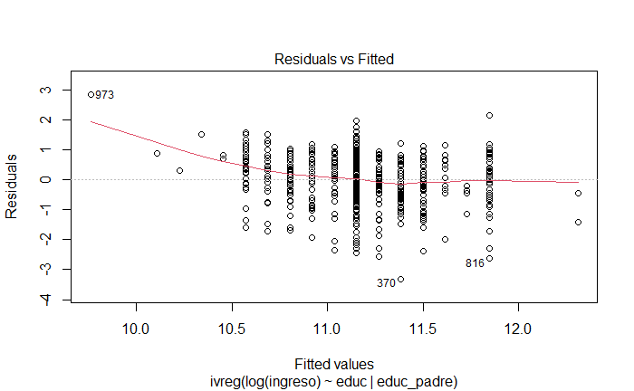

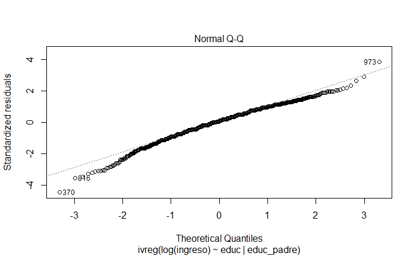

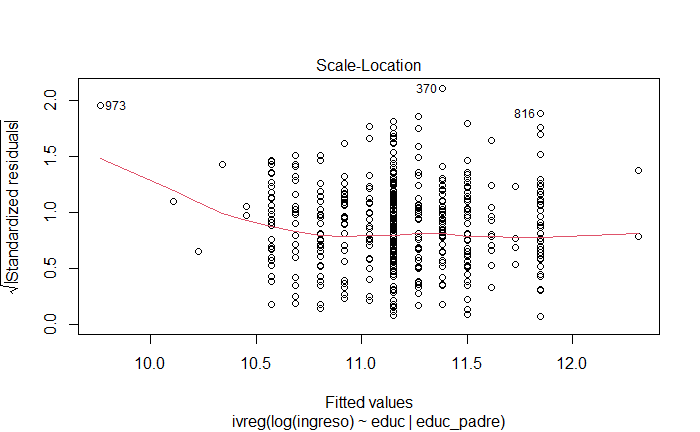

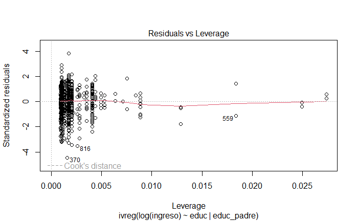

```r
plot(modelo_2)
```